# Estimating and Interpreting Effect Sizes

A Note for 432 Class 16

Thomas E. Love

2018-03-08

# A Sample Data Set

Consider the `small.csv` data available on our site, which is modeled on the public Framingham data set available [from BIOLINCC](https://biolincc.nhlbi.nih.gov/teaching/). From the BIOLINCC documentation:

The Framingham data from this source are not appropriate for publication or project use because they have been anonymized by permuting the results of individual subjects.

> The Framingham Heart Study is a long term prospective study of the etiology of cardiovascular disease among a population of free living subjects in the community of Framingham, Massachusetts. The Framingham Heart Study was a landmark study in epidemiology in that it was the first prospective study of cardiovascular disease and identified the concept of risk factors and their joint effects.

## Available Variables

```r
smalldat <- read.csv("small.csv") %>% tbl_df
```

The `smalldat` data contains 150 observations on the following variables:

The *educ* levels are: 1_Low, 2_Middle, 3_High and 4_VHigh, which stands for Very High

| Variable | Description |
| --- | --- |
| *subject* | Subject identification code |
| *smoker* | 1 = current smoker, 0 = not current smoker |
| *totchol* | total cholesterol, in mg/dl |
| *age* | age in years |
| *sex* | subject’s sex (M or F) |
| *educ* | subject’s educational attainment (4 levels) |

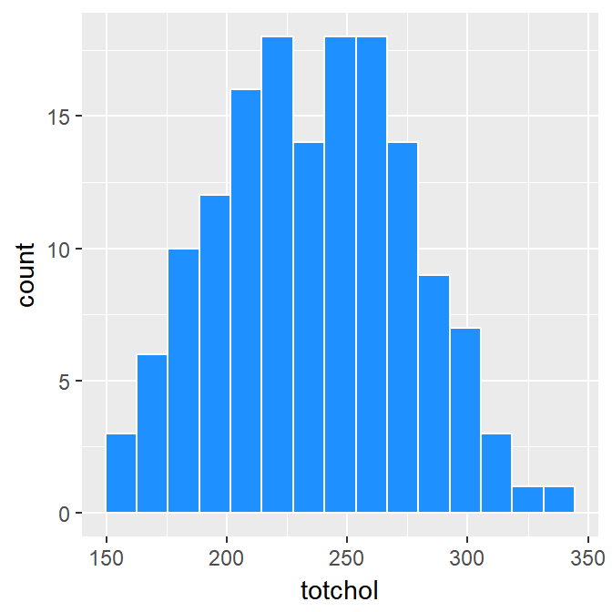

Histogram of totchol values

# Effect Interpretation in A Linear Regression Model

```r
m1 <- lm(totchol ~ age + sex + factor(educ),
         data = smalldat)

kable(tidy(m1, conf.int = TRUE), digits = 3)
```

| term | estimate | std.error | statistic | p.value | conf.low | conf.high |
| --- | --- | --- | --- | --- | --- | --- |
| (Intercept) | 171.197 | 20.201 | 8.475 | 0.000 | 131.268 | 211.126 |
| age | 1.202 | 0.367 | 3.270 | 0.001 | 0.475 | 1.928 |
| sexM | 3.612 | 6.441 | 0.561 | 0.576 | -9.119 | 16.343 |
| factor(educ)2_Middle | 11.044 | 7.702 | 1.434 | 0.154 | -4.180 | 26.268 |
| factor(educ)3_High | -2.459 | 9.390 | -0.262 | 0.794 | -21.019 | 16.101 |
| factor(educ)4_VHigh | 10.927 | 9.780 | 1.117 | 0.266 | -8.405 | 30.258 |

1. What is the effect of *age* on *totchol* in Model `m1`?

| term | estimate | std.error | statistic | p.value | conf.low | conf.high |
| --- | --- | --- | --- | --- | --- | --- |
| age | 1.202 | 0.367 | 3.27 | 0.001 | 0.475 | 1.928 |

The coefficient of the *age* effect on *totchol* is 1.202. Suppose we have two subjects, Doris and Emily, who are the same sex and have the same level of education, but Doris is one year older than Emily. Our model predicts that Doris’ total cholesterol will be 1.202 mg/dl higher than Emily’s.

The 95% confidence interval for this estimated *age* coefficient is (0.475, 1.928), which does not include zero, so we can conclude that there is a statistically significant effect (at the 5% significance level) of *age* on *totchol*. Holding everything else constant, older *age* is associated with significantly higher *totchol* in this model.

2. What is the effect of *sex* on `totchol` in Model `m1`?

| term | estimate | std.error | statistic | p.value | conf.low | conf.high |
| --- | --- | --- | --- | --- | --- | --- |
| sexM | 3.612 | 6.441 | 0.561 | 0.576 | -9.119 | 16.343 |

The model is parametrized to incorporate the *sex* information with an indicator (and factor) variable called *sexM* which is interpreted as taking the value 1 when *sex* = M, and 0 otherwise. The coefficient of the *sexM* effect on *totchol* is 3.612. Suppose we have two subjects, David and Emily, who are the same age, have the same level of education, but David is male and Emily is female. Our model predicts that David’s total cholesterol will be 3.612 mg/dl higher than Emily’s.

The 95% confidence interval for this estimated *sexM* coefficient is (-9.119, 16.343), which includes zero, so we cannot conclude that there is a statistically significant effect (at the 5% significance level) of *sex* on *totchol*.

3. What is the effect of *educ* on *totchol* in Model `m1`?

The *educ* variable splits the subjects into four categories. In this model the “1_Low” category is used as the baseline, and we have estimates for “2_Middle” (as compared to “1_Low”), for “3_High” (as compared to “1_Low”) and for “4_VHigh” (as compared to “1_Low”.)

| term | estimate | std.error | statistic | p.value | conf.low | conf.high |
| --- | --- | --- | --- | --- | --- | --- |
| factor(educ)2_Middle | 11.044 | 7.702 | 1.434 | 0.154 | -4.180 | 26.268 |
| factor(educ)3_High | -2.459 | 9.390 | -0.262 | 0.794 | -21.019 | 16.101 |
| factor(educ)4_VHigh | 10.927 | 9.780 | 1.117 | 0.266 | -8.405 | 30.258 |

The coefficient of the *educ* effect comparing the “2_Middle” group to the baseline “1_Low” group on *totchol* is 11.044.

Notice that none of the displayed *educ* levels show statistically significant differences from the baseline group, based on their 95% confidence intervals each containing zero.

- Suppose we have two subjects, Lola and Mina, who are the same age, and the same sex, but Lola is in the “1_Low” education group and Mina is in the “2_Middle” education group.
- Our model predicts that Mina’s total cholesterol will be 11.044 mg/dl higher than Lola’s.

The coefficient of the *educ* effect comparing the “3_High” group to the baseline “1_Low” group on *totchol* is -2.459.

- Suppose we have two subjects, Lola and Heidi, who are the same age, and the same sex, but Lola is in the “1_Low” education group and Heidi is in the “3_High” education group.
- Our model predicts that Heidi’s total cholesterol will be 2.459 mg/dl **lower** than Lola’s.

Finally, the coefficient of the *educ* effect comparing the “4_VHigh” group to the baseline “1_Low” group on *totchol* is 10.927.

- Suppose we have two subjects, Lola and Vera, who are the same age, and the same sex, but Lola is in the “1_Low” education group and Vera is in the “4_VHigh” education group.
- Our model predicts that Vera’s total cholesterol will be 10.927 mg/dl higher than Lola’s.

# What if we include a Spline or an Interaction?

Suppose we fit a new model to predict *totchol* using a five-knot spline in *age* and the interaction of sex and educational attainment. How does that change our interpretation of the effect sizes?

```r
d <- datadist(smalldat); options(datadist = "d")

m2 <- ols(totchol ~ rcs(age, 5) + sex*catg(educ),
         data = smalldat, x = TRUE, y = TRUE)

kable(summary(m2), digits = 2)
```

|  | Low | High | Diff. | Effect | S.E. | Lower 0.95 | Upper 0.95 | Type |
| --- | --- | --- | --- | --- | --- | --- | --- | --- |
| age | 42 | 57 | 15 | 9.99 | 9.40 | -8.59 | 28.57 | 1 |
| sex - M:F | 1 | 2 | NA | 9.11 | 9.87 | -10.41 | 28.64 | 1 |
| educ - 2_Middle:1_Low | 1 | 2 | NA | 11.36 | 9.81 | -8.04 | 30.76 | 1 |
| educ - 3_High:1_Low | 1 | 3 | NA | 7.80 | 12.41 | -16.73 | 32.34 | 1 |
| educ - 4_VHigh:1_Low | 1 | 4 | NA | 16.17 | 14.63 | -12.75 | 45.10 | 1 |

The `kable` approach I used in these notes hides the adjusted values specified at the bottom of the `summary` table for this `ols` model, but they are `Adjusted to: sex=F educ=1_Low`.

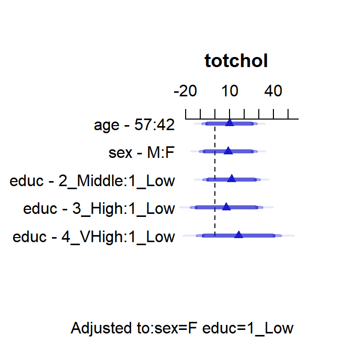

Summary plot of model m2

Now, how do we interpret these model `m2` results?

- The **age** interpretation is that if we have two subjects, Al and Bob, who are the same sex and have the same education level, but Al is age 42 and Bob is age 57, then model `m2` projects that Bob’s *totchol* will be 9.993 mg/dl higher than will Al’s.
- Because of the interaction between *sex* and *educ* in our model `m2`, we must select an *educ* level in order to cleanly interpret the effect of *sex* on *totchol*. The **sex - M:F** interpretation compares M(ale) to F(emale) *sex* while requiring that *educ* = `1_Low`. The result is that if we have two subjects, Carl and Diane, who are the same age and *each is in the low education group*, but Carl is Male and Diane is Female, then model `m2` predicts that Carl’s *totchol* will be 9.115 mg/dl higher than will Diane’s.

  We know this because of the `Adjusted to: sex = F, educ=1_Low` note at the bottom of the `summary` output for the `ols` model.
- Because of the interaction between *sex* and *educ* in our model `m2`, we must select a *sex* in order to cleanly interpret the effect of *educ* on *totchol*. The **educ - 2_Middle:1_Low** term, for instance, compares “2_Middle” education to “1_Low” education while requiring that *sex* is Female. The result is that if we have two subjects, Lola and Mina, who are the same age and *each is Female*, but Lola is in the “1_Low” education group and Mina is in the “2_Middle” education group, then model `m2` predicts that Mina’s *totchol* will be 11.363 mg/dl higher than will Lola’s.

  Again, we know this because of the `Adjusted to: sex = F, educ=1_Low` note.

Here is a nomogram of model `m2`.

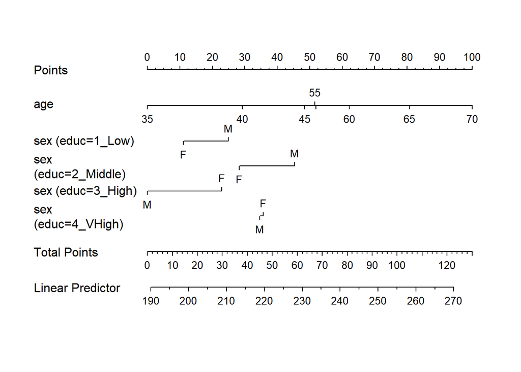

# Effect Estimates in A Logistic Regression fit with `glm`

In a binary **logistic** model, where we predict the log odds of smoking (*smoker* = 1), we will exponentiate so as to interpret the odds ratio estimates associated with each coefficient.

```r
m3 <- glm(smoker ~ age + sex + factor(educ),
         data = smalldat, family = binomial)

kable(tidy(m3, exponentiate = TRUE, conf.int = TRUE),
      digits = 3)
```

| term | estimate | std.error | statistic | p.value | conf.low | conf.high |
| --- | --- | --- | --- | --- | --- | --- |
| (Intercept) | 19.054 | 1.152 | 2.557 | 0.011 | 2.082 | 195.209 |
| age | 0.943 | 0.021 | -2.782 | 0.005 | 0.903 | 0.982 |
| sexM | 1.795 | 0.356 | 1.643 | 0.100 | 0.897 | 3.637 |
| factor(educ)2_Middle | 0.690 | 0.428 | -0.866 | 0.386 | 0.295 | 1.589 |
| factor(educ)3_High | 0.725 | 0.519 | -0.619 | 0.536 | 0.258 | 2.005 |
| factor(educ)4_VHigh | 0.339 | 0.571 | -1.895 | 0.058 | 0.105 | 1.008 |

1. What is the effect of *age* on the odds of being a *smoker* in Model `m3`?

| term | estimate | std.error | statistic | p.value | conf.low | conf.high |
| --- | --- | --- | --- | --- | --- | --- |
| age | 0.943 | 0.021 | -2.782 | 0.005 | 0.903 | 0.982 |

The estimated odds ratio for the *age* effect on *smoker* is 0.943. Suppose we have two subjects, Doris and Emily, who are the same sex and have the same level of education, but Doris is one year older than Emily. Our model predicts that Doris’ odds of smoking will be 0.943 times as high as Emily’s.

The 95% confidence interval for this estimated odds ratio for the *age* effect on being a *smoker* is (0.903, 0.982). This confidence interval for the odds ratio does not include one, so we can conclude that there is a statistically significant effect (at the 5% significance level) of *age* on *smoker*. Holding everything else constant, older *age* is associated with significantly lower odds of being a *smoker* in this model.

2. What is the effect of *sex* on the odds of being a *smoker* in Model `m3`?

| term | estimate | std.error | statistic | p.value | conf.low | conf.high |
| --- | --- | --- | --- | --- | --- | --- |
| sexM | 1.795 | 0.356 | 1.643 | 0.1 | 0.897 | 3.637 |

The model is parametrized to incorporate the *sex* information with an indicator (and factor) variable called *sexM* which is interpreted as taking the value 1 when *sex* = M, and 0 otherwise. The estimated odds ratio describing the *sexM* effect on being a *smoker* is 1.795. Suppose we have two subjects, David and Emily, who are the same age, have the same level of education, but David is male and Emily is female. Our model predicts that David’s odds of being a *smoker* are 1.795 times the odds that Emily is a *smoker*.

The 95% confidence interval for the odds ratio estimate of the effect of *sexM* on being a *smoker* is (0.897, 3.637). Since this confidence interval for the odds ratio includes one, we cannot conclude that there is a statistically significant effect (at the 5% significance level) of *sex* on the odds of being a *smoker*.

3. What is the effect of *educ* on the odds of being a *smoker* in Model `m3`?

Again, the *educ* variable splits the subjects into four categories. In this model the “1_Low” category is used as the baseline, and we have estimates for “2_Middle” (as compared to “1_Low”), for “3_High” (as compared to “1_Low”) and for “4_VHigh” (as compared to “1_Low”.)

| term | estimate | std.error | statistic | p.value | conf.low | conf.high |
| --- | --- | --- | --- | --- | --- | --- |
| factor(educ)2_Middle | 0.690 | 0.428 | -0.866 | 0.386 | 0.295 | 1.589 |
| factor(educ)3_High | 0.725 | 0.519 | -0.619 | 0.536 | 0.258 | 2.005 |
| factor(educ)4_VHigh | 0.339 | 0.571 | -1.895 | 0.058 | 0.105 | 1.008 |

The estimated odds ratio describing the effect of *educ* being “2_Middle” instead of the baseline “1_Low” on the odds of being a *smoker* is 0.69.

Notice that none of the displayed *educ* levels show statistically significant differences from the baseline group, based on their 95% confidence intervals all including 1, although the comparison of 4_VHigh to 1_Low is close to significant.

- Suppose we have two subjects, Lola and Mina, who are the same age, and the same sex, but Lola is in the “1_Low” education group and Mina is in the “2_Middle” education group.
- Our model predicts that Mina’s odds of being a smoker will be 0.69 times the odds of Lola being a smoker.

The estimated odds ratio comparing the *educ* = “3_High” group to the baseline *educ* = “1_Low” group on *smoker* is 0.725.

- Suppose we have two subjects, Lola and Heidi, who are the same age, and the same sex, but Lola is in the “1_Low” education group and Heidi is in the “3_High” education group.
- Our model predicts that Heidi’s odds of being a *smoker* will be 0.725 times the odds of Lola being a smoker.

Finally, The estimated odds ratio comparing the *educ* = “4_VHigh” group to the baseline *educ* = “1_Low” group on *smoker* is 0.339.

- Suppose we have two subjects, Lola and Vera, who are the same age, and the same sex, but Lola is in the “1_Low” education group and Vera is in the “4_VHigh” education group.
- Our model predicts that Vera’s odds of being a *smoker* will be 0.339 times the odds of Lola being a smoker.

# Estimates in The Same Logistic Regression fit with `lrm`

```r
d <- datadist(smalldat); options(datadist = "d")

m3.lrm <- lrm(smoker ~ age + sex + educ,
         data = smalldat, x = TRUE, y = TRUE)

kable(summary(m3.lrm), digits = 3)
```

|  | Low | High | Diff. | Effect | S.E. | Lower 0.95 | Upper 0.95 | Type |
| --- | --- | --- | --- | --- | --- | --- | --- | --- |
| age | 42 | 57 | 15 | -0.885 | 0.318 | -1.508 | -0.261 | 1 |
| Odds Ratio | 42 | 57 | 15 | 0.413 | NA | 0.221 | 0.770 | 2 |
| sex - M:F | 1 | 2 | NA | 0.585 | 0.356 | -0.113 | 1.283 | 1 |
| Odds Ratio | 1 | 2 | NA | 1.795 | NA | 0.893 | 3.607 | 2 |
| educ - 2_Middle:1_Low | 1 | 2 | NA | -0.370 | 0.428 | -1.209 | 0.468 | 1 |
| Odds Ratio | 1 | 2 | NA | 0.690 | NA | 0.299 | 1.596 | 2 |
| educ - 3_High:1_Low | 1 | 3 | NA | -0.321 | 0.519 | -1.338 | 0.696 | 1 |
| Odds Ratio | 1 | 3 | NA | 0.725 | NA | 0.262 | 2.005 | 2 |
| educ - 4_VHigh:1_Low | 1 | 4 | NA | -1.082 | 0.571 | -2.201 | 0.037 | 1 |
| Odds Ratio | 1 | 4 | NA | 0.339 | NA | 0.111 | 1.038 | 2 |

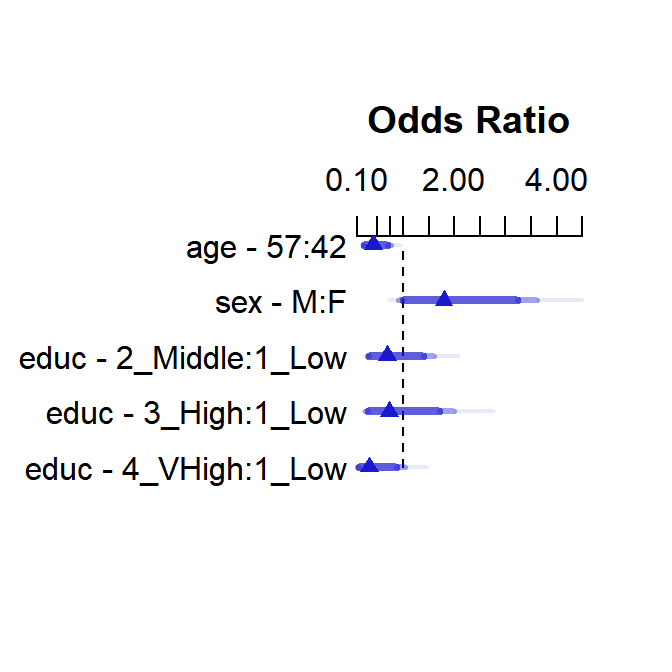

Summary plot of model m3.lrm

- The **age** interpretation is that if we have two subjects, Al and Bob, who are the same sex and have the same education level, but Al is age 42 and Bob is age 57, then model `m3` projects that Bob’s odds of being a *smoker* will be 0.413 times higher than will Al’s odds of being a smoker.
- Note that the effect of *age* on the odds of being a *smoker* is still statistically significant at the 5% level, because the confidence interval for the odds ratio does not contain 1. Since it is entirely less than 1, we can conclude that in this model, after adjustment for *sex* and *educ*, increasing age is associated with decreasing odds of smoking.

# Estimates in A New Logistic Regression fit with `lrm`

Now, suppose we fit a new model to predict the log odds of being a *smoker* using a five-knot spline in *age* and the interaction of sex and educational attainment. How does that change our interpretation of the effect sizes?

It should be easy to see that one is contained in each of the 95% confidence intervals summarizing model m4 except for the one for the main effect of sex, but we should make significance decisions for this model using anova, since an interaction is involved.

```r
d <- datadist(smalldat); options(datadist = "d")

m4 <- lrm(smoker ~ rcs(age,5) + sex * catg(educ),
         data = smalldat, x = TRUE, y = TRUE)

kable(summary(m4), digits = 3)
```

|  | Low | High | Diff. | Effect | S.E. | Lower 0.95 | Upper 0.95 | Type |
| --- | --- | --- | --- | --- | --- | --- | --- | --- |
| age | 42 | 57 | 15 | -0.817 | 0.538 | -1.872 | 0.237 | 1 |
| Odds Ratio | 42 | 57 | 15 | 0.442 | NA | 0.154 | 1.268 | 2 |
| sex - M:F | 1 | 2 | NA | 1.487 | 0.583 | 0.345 | 2.629 | 1 |
| Odds Ratio | 1 | 2 | NA | 4.422 | NA | 1.412 | 13.853 | 2 |
| educ - 2_Middle:1_Low | 1 | 2 | NA | 0.668 | 0.546 | -0.402 | 1.739 | 1 |
| Odds Ratio | 1 | 2 | NA | 1.951 | NA | 0.669 | 5.690 | 2 |
| educ - 3_High:1_Low | 1 | 3 | NA | 0.019 | 0.699 | -1.351 | 1.389 | 1 |
| Odds Ratio | 1 | 3 | NA | 1.019 | NA | 0.259 | 4.011 | 2 |
| educ - 4_VHigh:1_Low | 1 | 4 | NA | -1.541 | 1.159 | -3.813 | 0.731 | 1 |
| Odds Ratio | 1 | 4 | NA | 0.214 | NA | 0.022 | 2.078 | 2 |

Again, the `kable` approach I used in these notes hides the adjusted values specified at the bottom of the `summary` table for this `lrm` model (model `m4`), but they are `Adjusted to: sex=F educ=1_Low`.

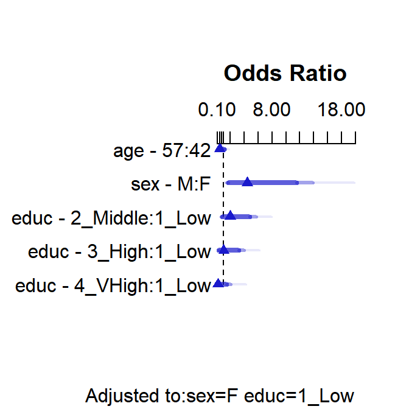

Summary plot of model m4

Now, how do we interpret these model `m4` results?

- The **age** interpretation is that if we have two subjects, Al and Bob, who are the same sex and have the same education level, but Al is age 42 and Bob is age 57, then model `m4` projects that Bob’s odds of being a smoker will be 0.442 times higher than Al’s odds of being a smoker.
- Because of the interaction between *sex* and *educ* in our model `m4`, we must select an *educ* level in order to cleanly interpret the effect of *sex* on *smoker*. The **sex - M:F** interpretation compares M(ale) to F(emale) *sex* while requiring that *educ* = `1_Low`. The result is that if we have two subjects, Carl and Diane, who are the same age and *each is in the low education group*, but Carl is Male and Diane is Female, then model `m4` predicts that Carl’s odds of being a *smoker* will be 4.422 times higher than will Diane’s.

  We know this because of the `Adjusted to: sex = F, educ=1_Low` note at the bottom of the `summary` output.
- Because of the interaction between *sex* and *educ* in our model `m4`, we must select a *sex* in order to cleanly interpret the effect of *educ* on *totchol*. The **educ - 2_Middle:1_Low** term, for instance, compares “2_Middle” education to “1_Low” education while requiring that *sex* is Female. The result is that if we have two subjects, Lola and Mina, who are the same age and *each is Female*, but Lola is in the “1_Low” education group and Mina is in the “2_Middle” education group, then model `m4` predicts that Mina’s odds of being a *smoker* will be 1.951 times higher than will Lola’s.

  `Adjusted to: sex = F, educ=1_Low` tells us this.

Here is a nomogram of model `m4`.

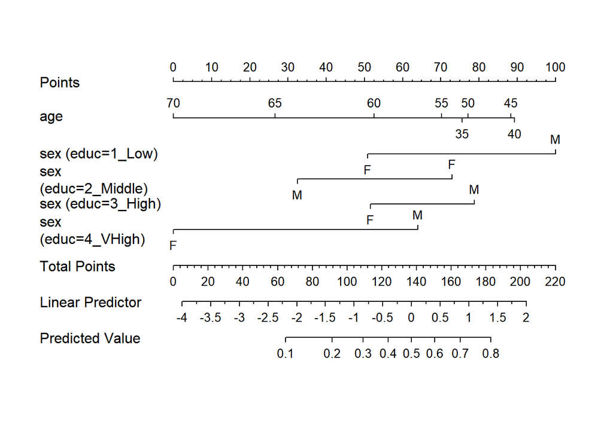